# מקורות מידע לqgis

ד”ר עדו קליין

# הקדמה לקורס

קורס זה מיועד למקצע את עובדות חברת ארא בשימוש בqgis.

### קצת על עצמי

עדו קליין, 37, נשוי להילה, אב ל4.

חיפאי במקור, ירושלמי בהווה.

בעל תואר ראשון בפילוסופיה, כלכלה ומדעי המדינה מהאוניברסיטה העברית (2009-2012), תואר שני בגאוגרפיה ותכנון עירוני מהאוניברסיטה העברית (2012-2014) , ותואר שלישי בגאוגרפיה מאוניברסיטת בן גוריון בנגב (2014-2018).

בוגר תכנית ממשק של האגודה הישראלית לאקולוגיה, התמחות במשרד התחבורה תחת שי קדם, כיום משנה למנכ”ל.

כיום יועץ למשרד התחבורה בנושא מודלים ואיסוף מידע תחבורתי, ויועץ לצוות אב לתחבורה ירושלים במסגרת התכנית האסטרטגית למתע”ן.

# מערך הקורס - מתחילים:

- בסיס
  - סוגי שכבות
  - סוגי קבצים
  - טעינת שכבות
  - עבודה בפרויקט
- סימבולוגיה
  - פאנל הסגנון
  - סוגי סימבולוגיה
  - תגיות
  - יצירת מפה
- ניתוח נתונים בסיסי
  - טבלת הישויות
  - בחירה
  - שאילתות טבלאיות
  - שאילתות מרחביות
- עריכת נתונים
  - דיגיטציה
  - עריכת טבלאות
- מניפולציה מרחבית
  - פונקציות מרחביות
  - model builder
- מקורות מידע לתכנון תחבורה
  - אתרים
  - סרויסים
  - שו”תים

# מערך הקורס - מתקדמים:

- פלאגינים
- הורדת מידע מOSM

# מהו GIS

מערכת מידע גאוגרפית - מערכת ששומרת על מידע מרחבי בצורה מסודרת, ומאפשרת את עיבודו, ניתוחו, הצגתו, יצירתו וניהולו.

# סוגי מידע גאוגרפי

ישנם שני סוגי מידע גאוגרפי מרכזיים:

- מידע רסטרי

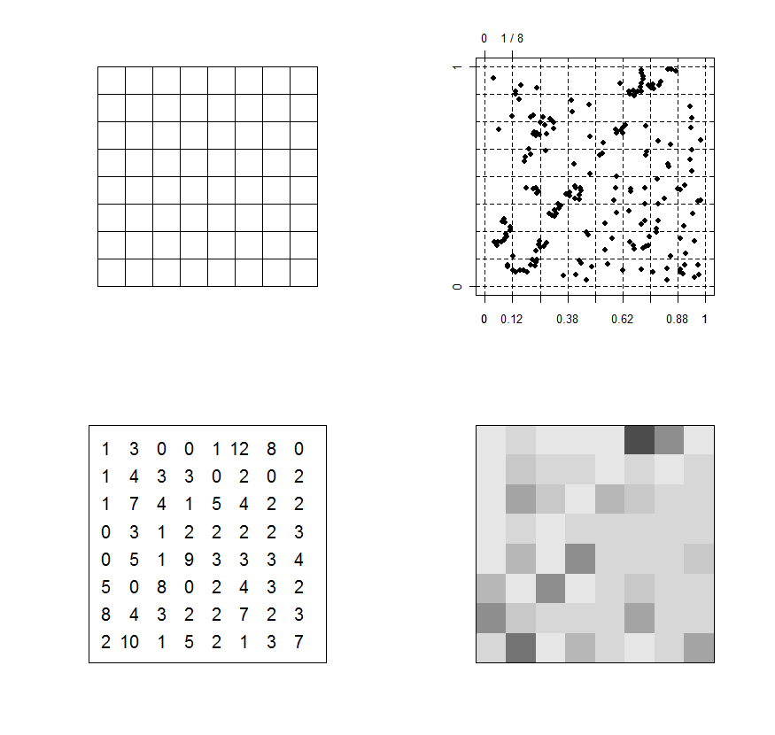

- מידע וקטורי

[figure not shown]

בקורס זה ניגע כמעט ורק במידע וקטורי.

# סוגי מידע וקטורי

כשאנו מתעסקים עם מידע וקטורי, אני מתעסקים עם שלושה סוגים מרכזיים של ישויות:

- נקודות
- קווים
- פוליגונים

את כל אחת מהסוגים האלה ניתן לייצג על ידי רצף של קואורדינטות:

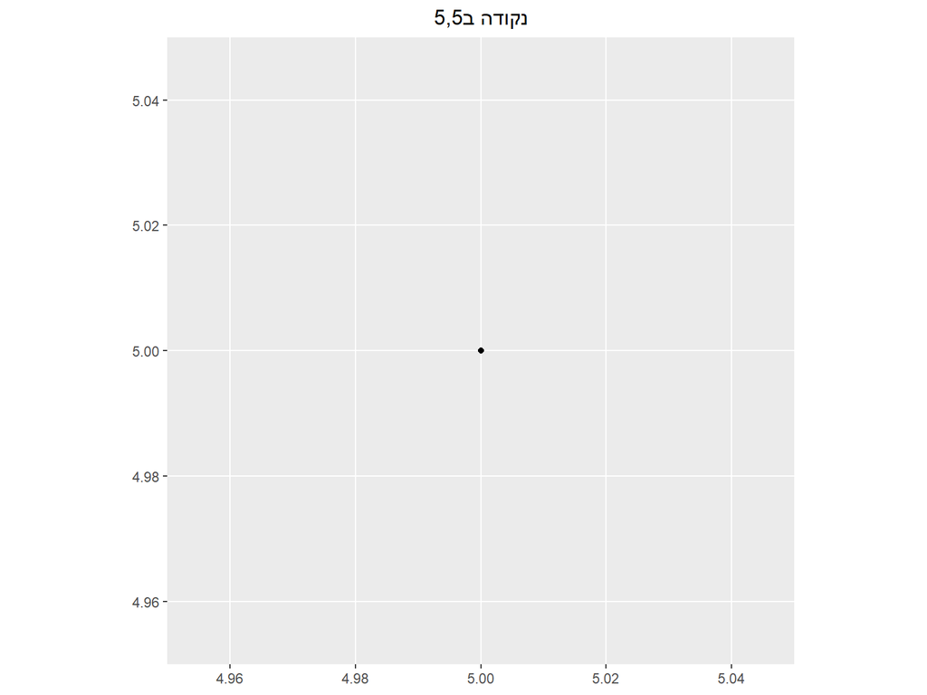

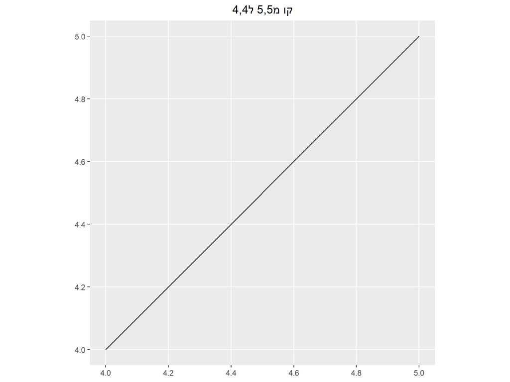

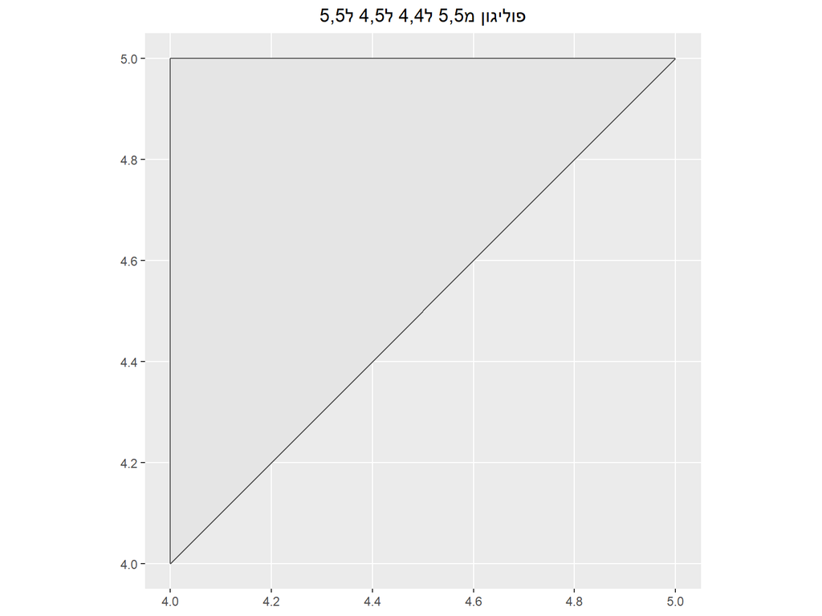

# מידע וקטורי - שם מפוצץ לטבלה

אך לפני זה, חשוב להבין שgis הוא פשוט טבלה מלאה במידע, שלפחות אחת מעמודות הטבלה מכילה מידע גאוגרפי,כמו בטבלה הזאת:

| מזהה | שם | גיל | מיקום |
| --- | --- | --- | --- |
| 1 | אביעד | 65 | 1,1 |
| 2 | רפי | 23 | 26,41 |
| 3 | ניסן | 32 | 31,82 |
| 4 | אביאל | 74 | 93,49 |

מכיוון שחלק מהמידע הגאומטרי הוא מסובך לקידוד, בהתחשב בהיטלים הגאוגרפיים ובמורכבות הישות, הוספה של עמודת הגאומטריה לטבלה לא מועילה (אך בפלטפורמות אחרות, כמו R או POSTGIS, היא מופיעה).

בשכבה זו, לצורך העניין, יש ארבע ישויות שונות, כאשר כל ישות מסמלת נקודה אחת.

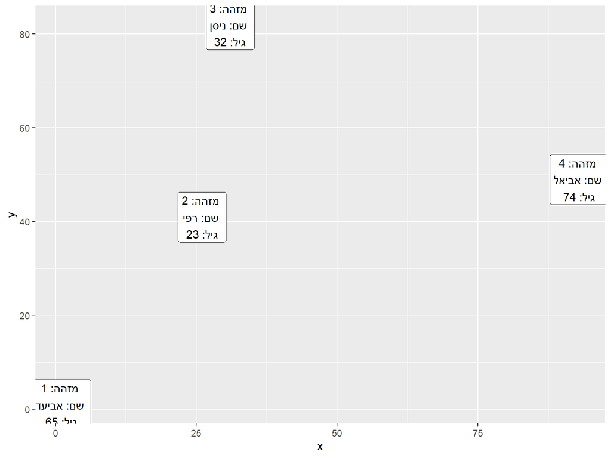

# מימדים נוספים במידע וקטורי

מעבר לסוגי הישויות, קיימים היבטים נוספים עבור כל ישות:

- ישות מרובה צורות - ישות אחת יכולה להכיל מספר נקודות/קווים/פוליגונים

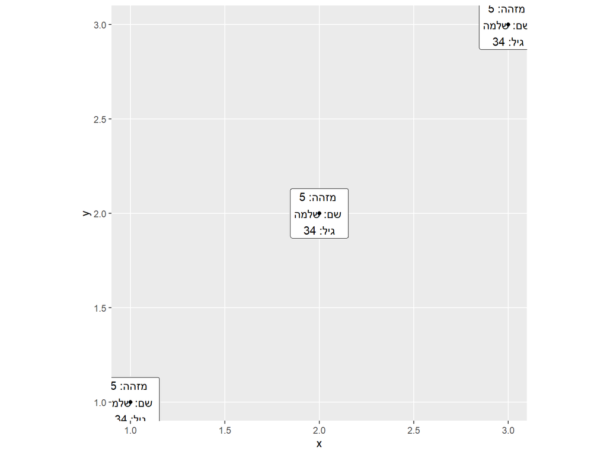

- תלת מימד - ניתן להוסיף לקוארדינטות מימד גובה

שוב, נזכיר - שכבה היא בעצם טבלה עם גאומטריה, וכמו שעל עמודה בטבלה ניתן לבצע פעולות חישוביות, כך גם על ישויות,ועל כך נרחיב בהמשך הקורס.

# סוגי קבצים

ניתן לחלק את סוגי הקבצים לשניים:

- קבצים בודדים
- חבילות קבצים

# קבצים בודדים[1]

#### shapefile (.shp and more)

הshp, פורמט שייצרה חברת esri, מכיל מספר קבצים שכאשר נמצאים באותה תיקיה, יוצרים אפשרות לצפות בישויות שונות, תחת מגבלות מסוימות:

- הפורמט זקוק ללפחות שלושה קבצים על מנת לפעול(צורות מרחביות, מאגר נתונים מרחבי ואינדקס מרחבי, ובדרך כלל ליותר מכך

[figure not shown]

- עמודה מכילה סוג גאומטריה אחד בלבד
- יש עמודת גאומטריה אחת בלבד

בזמנכן הפנוי - היטלים ומערכת קואורדיטות:

[הסבר קליט](https://www.youtube.com/watch?v=kIID5FDi2JQ)

מצגת של הראל דן על ההקשר הישראלי - חשוב להכיר

# הדגמה של טעינת שכבות ועבודה בסיסית

# תרגיל ראשון:

[figure not shown]

2. שימו לב שהשכבה נכנסה ללשונית השכבות

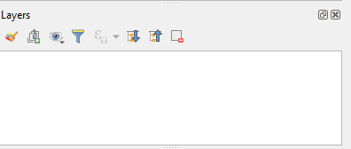

3. טענו את שכבת הרקע של osm

[figure not shown]

4. השתמשו בכפתורי סרגל הניווט. אל תתביישו להתנסות

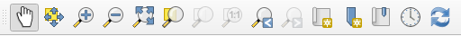

5. פתחו את טבלת הפיצ’רים וחקרו אותם

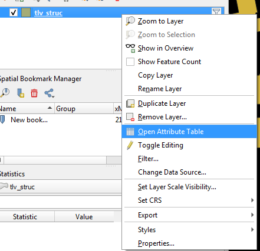

6. ענו על השאלות הבאות:
   1. כמה בניינים יש בשכבה?
   2. באיזה רחוב נמצא הבניין העתיק ביותר?
   3. באיזה רחוב נמצא הבניין הצפוני ביותר?

# קבצים בודדים[2]

#### .geojson

פורמט המייצג גאומטריות בפורמט json לשמירת נתונים, מכיל רק נתונים המתאימים לרשת גאוגרפית wgs84.

כפי שניתן לראות, הנתונים בgeojson הינם טקסטואלים, מה שאומר שניתן לפתוח אותם בכל עורך טקסט ולצפות או לשנות אותם משם, זת בניגוד לקבצי שייפ המבוססים על מבנה נתונים שלא קריא לבני אדם.

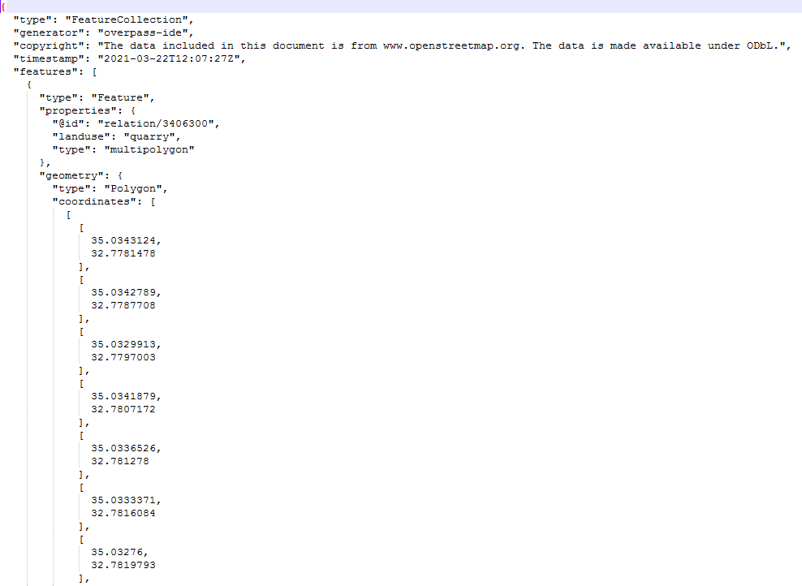

# תרגיל שני:

1. טענו את הקובץ, שימו לב למיקום הנקודות, בחרו את הנקודה הצפונית ביותר ורשמו את המזהה שלה. הסירו את השכבה
2. פתחו את הקובץ בnotepad, הזיזו את הנקודה דרומה, שמרו את הקובץ
3. טענו מחדש את השכבה וצפו בהבדל

# קבצים בודדים[3]

#### .csv

ניתן לטעון קובץ טבלאי רגיל, באחת משלוש דרכים:

1. על ידי ציון קואורדינטות - עמודות המייצגות קו אורך וקו רוחב - מאפשר טעינה של נקודות בלבד
2. עמודה המציינת wkt - מאפשר טעינה של כל סוגי הגאומטריה הנתמכים על ידי wkt
3. על ידי אי ציון גאומטריה. משמש בעיקר לחיבורים טבלאיים

# תרגיל שלישי:

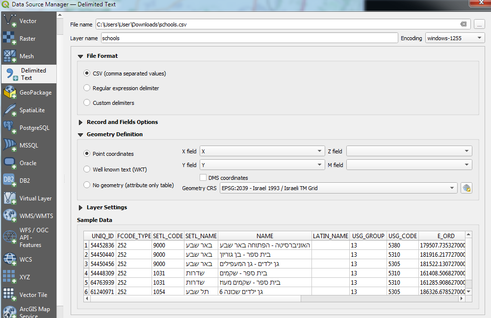

3. דגשים: לדעת איזה שדות להכניס לx וy, לדעת איזה מערכת קואורדינטות לבחור (בתשעה מתוך 10 מקרים של מידע ישראלי, זאת תהיה רשת ישראל החדשה, שהסימון שלה בepsg הוא 2039), ולבסוף - במידה והעברית מתחרבשת - לשחק עם הencoding. לרוב או utf8 או windows1255